# 2021 Q

### Predicted Q for POKE PT1

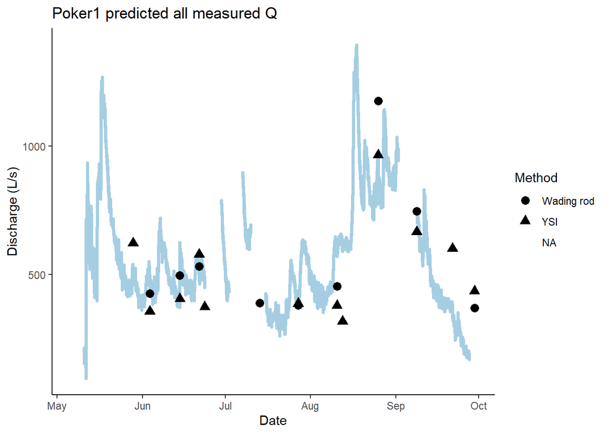

Not the prettiest thing I have ever seen

### Predicted Q for POKE PT2

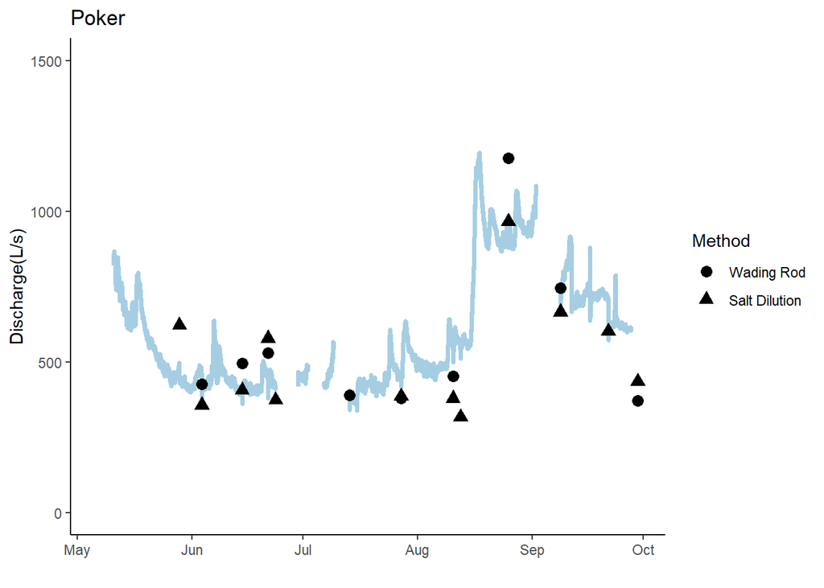

Looks better then PT1…snowmelt signature looks good

### Average Q for POKE

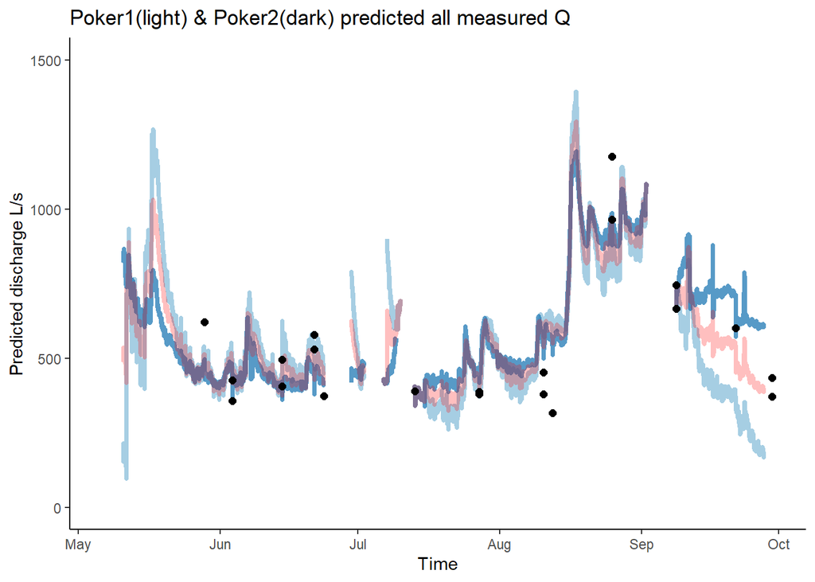

I think I should clip off the beginning of PT1 as the snowmelt signature makes more sense in PT2…what do you think?

Lets use PT2 before May 20th and PT1 only after September 5th.

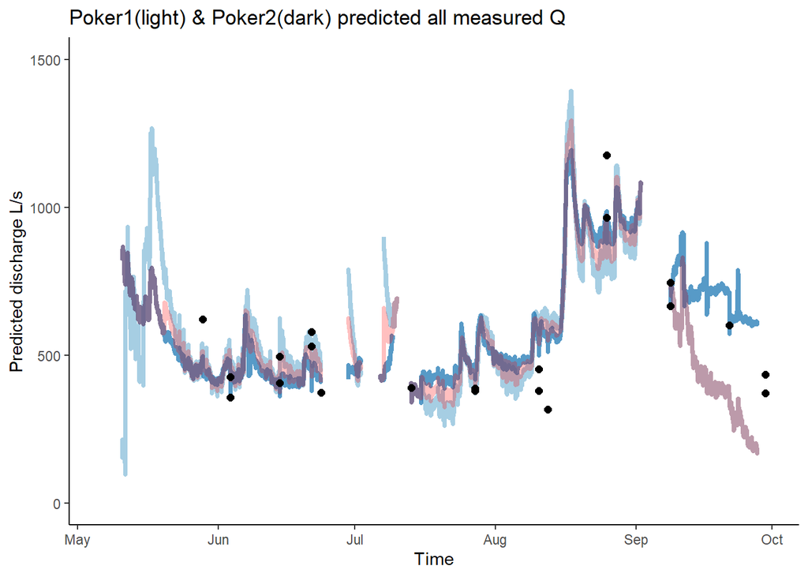

```r
poke.final.discharge.2021.2 <- poke.final.discharge.2021 %>% mutate(across(c(MeanDischarge), ~ifelse(DateTime < "2021-05-20", pred.poke2.Q,.)))

poke.final.discharge.2021.2 <- poke.final.discharge.2021.2 %>% mutate(across(c(MeanDischarge), ~ifelse(DateTime > "2021-09-05", pred.poke1.Q,.)))

# Poker1 (light blue) and Poker2 (dark blue) with observed Q.
ggplot(aes(x = DateTime, y = pred.poke1.Q), data = Poke1comb.2021) +
  geom_line(aes(x = DateTime, y = pred.poke1.Q), data = Poke1comb.2021, color="#A6CEE3", size=1.25) +
  geom_line(aes(x = DateTime, y = pred.poke2.Q), data = Poke2comb.2021,color="#1F78B4", size=1.25, alpha = 0.75) +
  geom_line(aes(x = DateTime, y = MeanDischarge), data = poke.final.discharge.2021.2, color = "red", size = 1.25, alpha = 0.25) +
  geom_point(aes(x = DateTime, y = MeasuredQ_Ls), size=2) +
  theme_classic() +
  ylim(0, 1500) +
  ggtitle("Poker1(light) & Poker2(dark) predicted all measured Q") +
  ylab("Predicted discharge L/s") +
  xlab("Time")
```

## Export Q data to csv in DoD_Discharge->Predicted_discharge->2021

### Raw Vault PT1

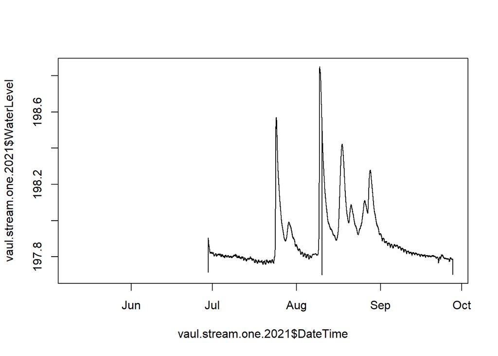

Need to remove vertical bars associated with out of water points such as the beginning and the end of the dataframe

### Vault PT1 2.0

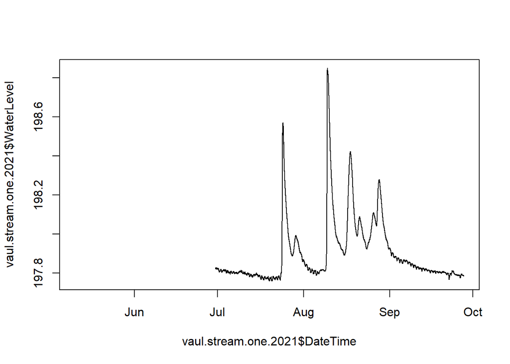

## Export PT data to csv in DoD_Discharge->PT_data->2021

### Raw VAUL rating curve

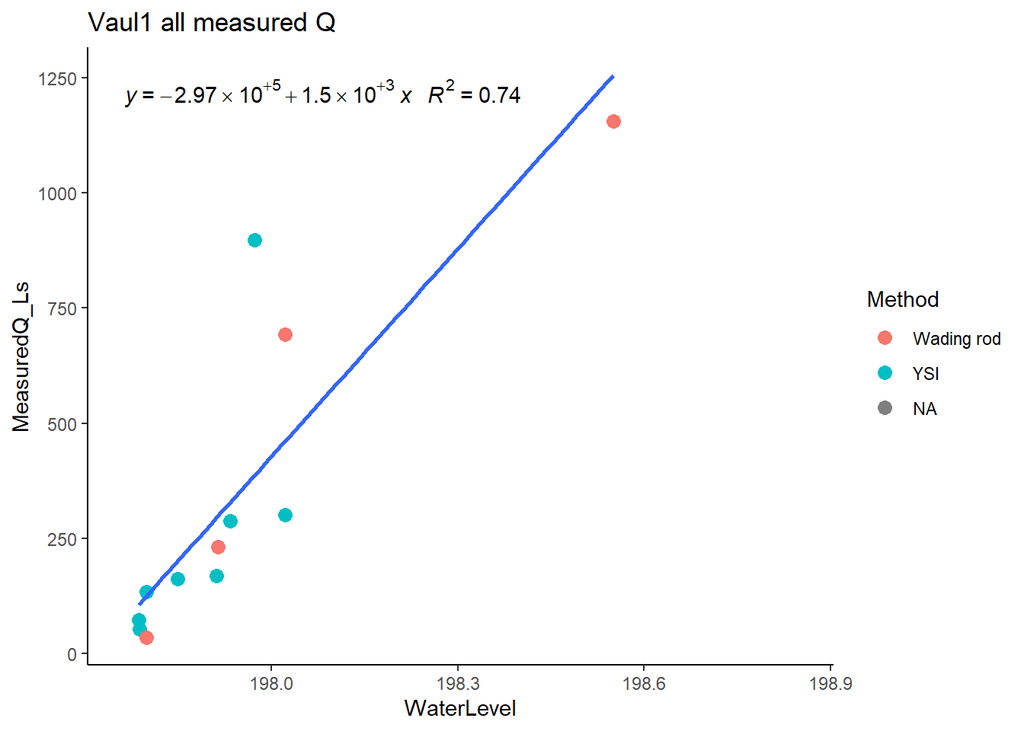

Best raw one yet!

### Predicted Q for VAUL

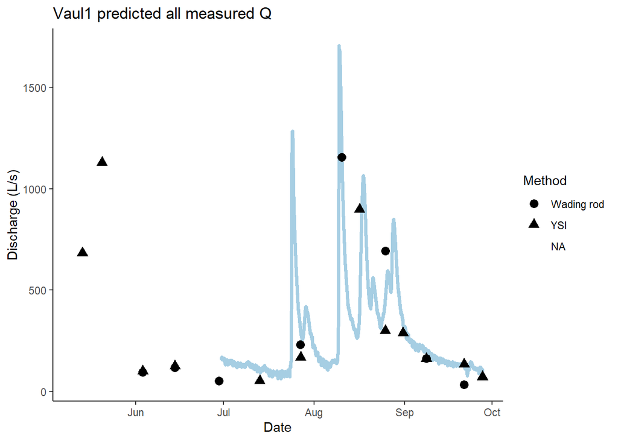

Not too shabby

## Export Q data to csv in DoD_Discharge->Predicted_discharge->2021

### Raw STRT PT1

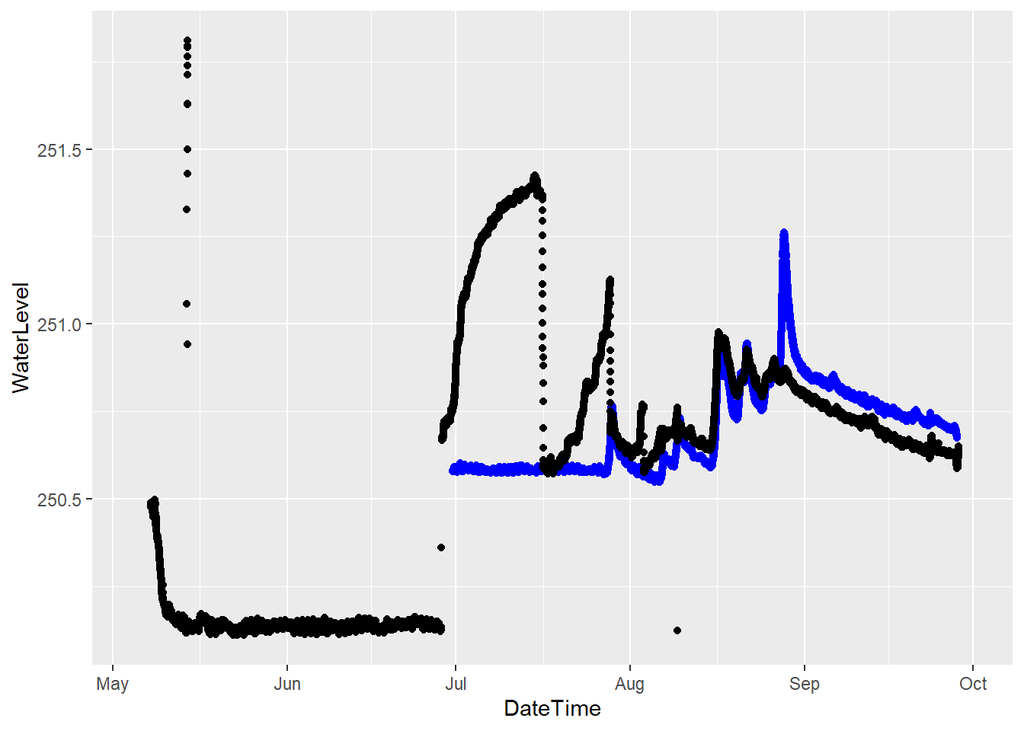

Need to shift beginning of dataframe up and remove beaverr dam in July…remove errant vertical bars

### STRT PT1 2.0

```
## [1] 0.543
```

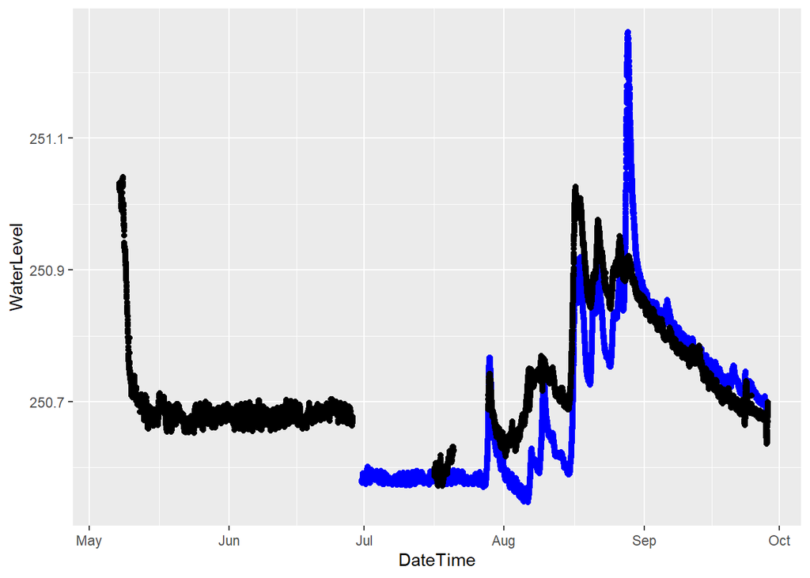

1. Removed errant vertical bar points 2)Removed beaver dam raises in Water level Quick snowmelt period and then not a lot of waterlevel change in June.

### Raw STRT PT2

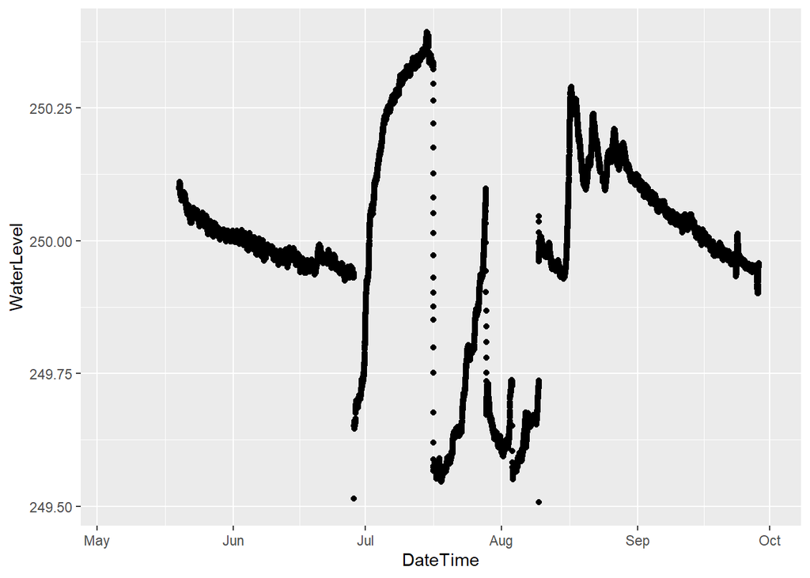

### STRT PT2 2.0

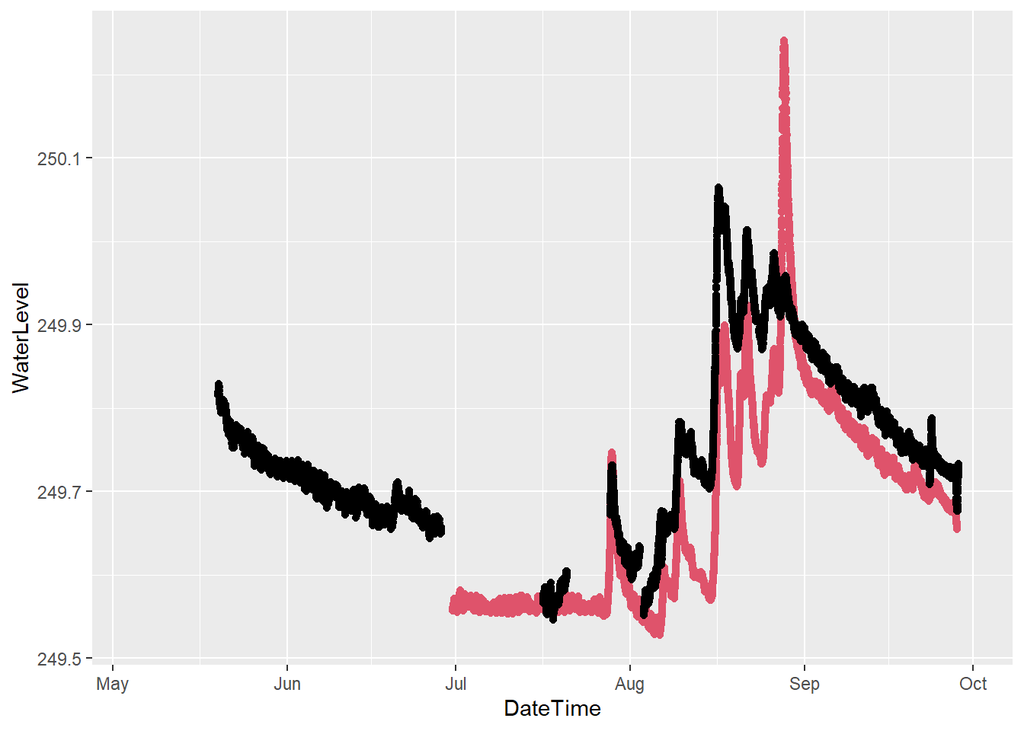

1. removed beaver dams
2. removed errant vertical bars
3. shifted middle of july to middle of August

## Export PT data to csv in DoD_Discharge->PT_data->2021

### Raw STRT rating curve

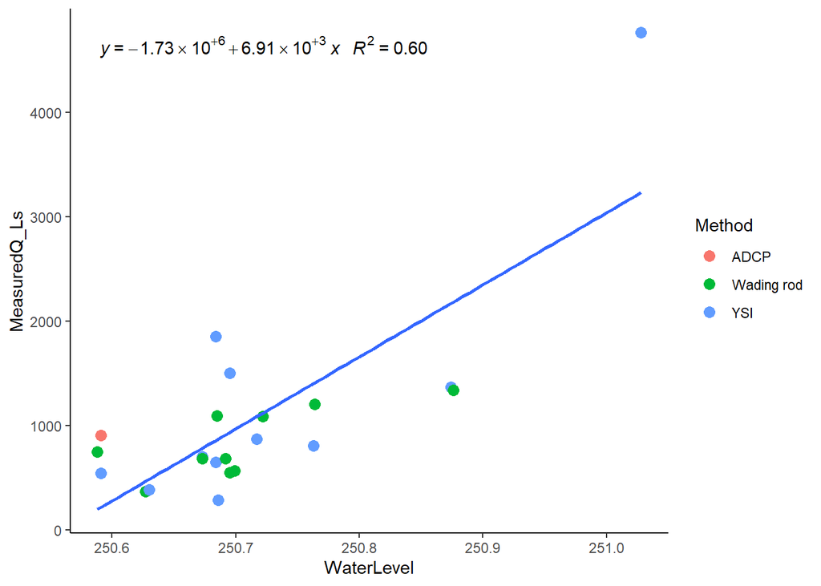

```
## $title
## [1] "Strt1 all measured Q"
##
## attr(,"class")
## [1] "labels"
```

I will remove some YSI points, and lowest wadinging rod and ADCP point. ### STRT rating curve 2.0

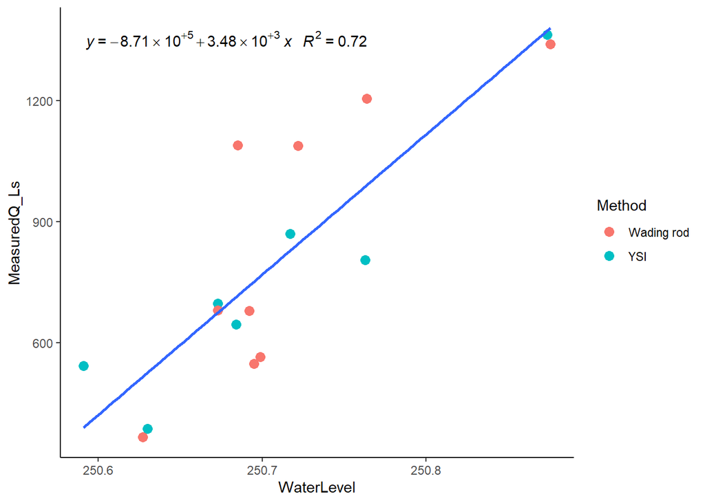

```
## $title
## [1] "Strt1 all measured Q"
##
## attr(,"class")
## [1] "labels"
```

### Raw STRT rating curve PT2

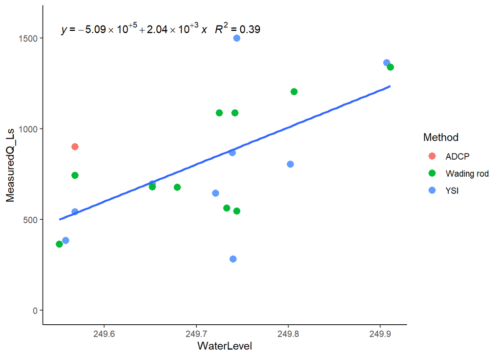

```
## $title
## [1] "Stuart2 all measured Q"
##
## attr(,"class")
## [1] "labels"
```

### STRT rating curve PT2 2.0

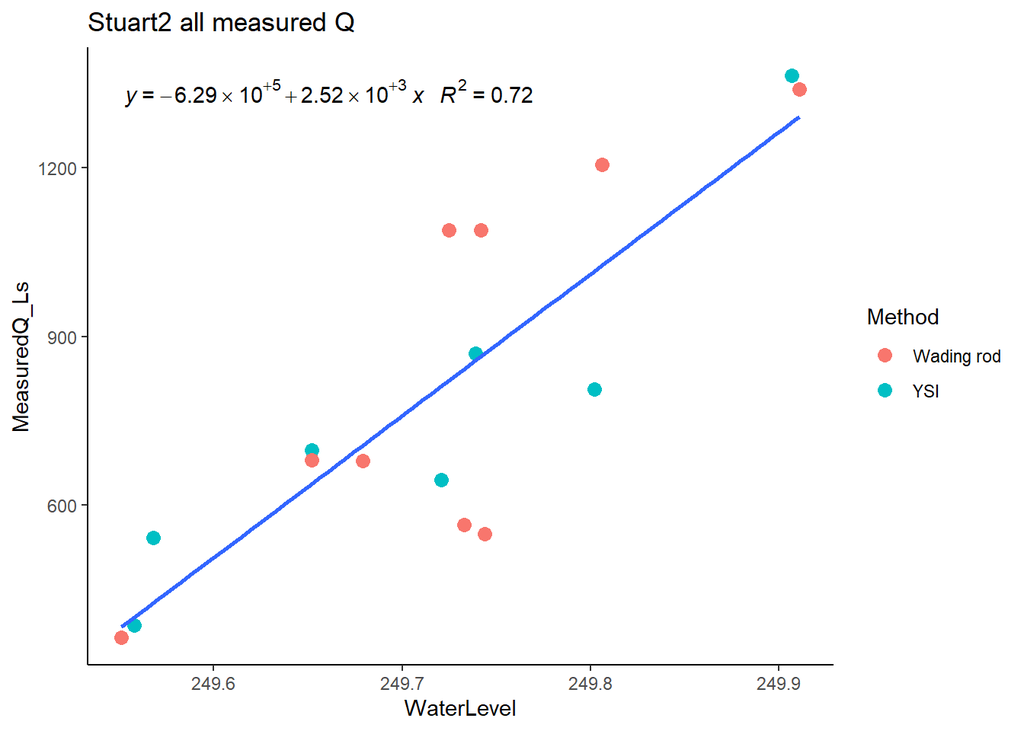

### Predicted Q STRT PT1

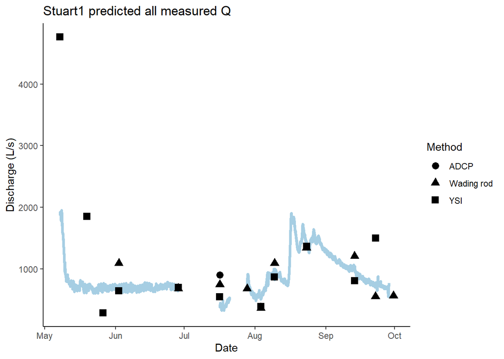

Icky

### Predicted Q STRT PT2

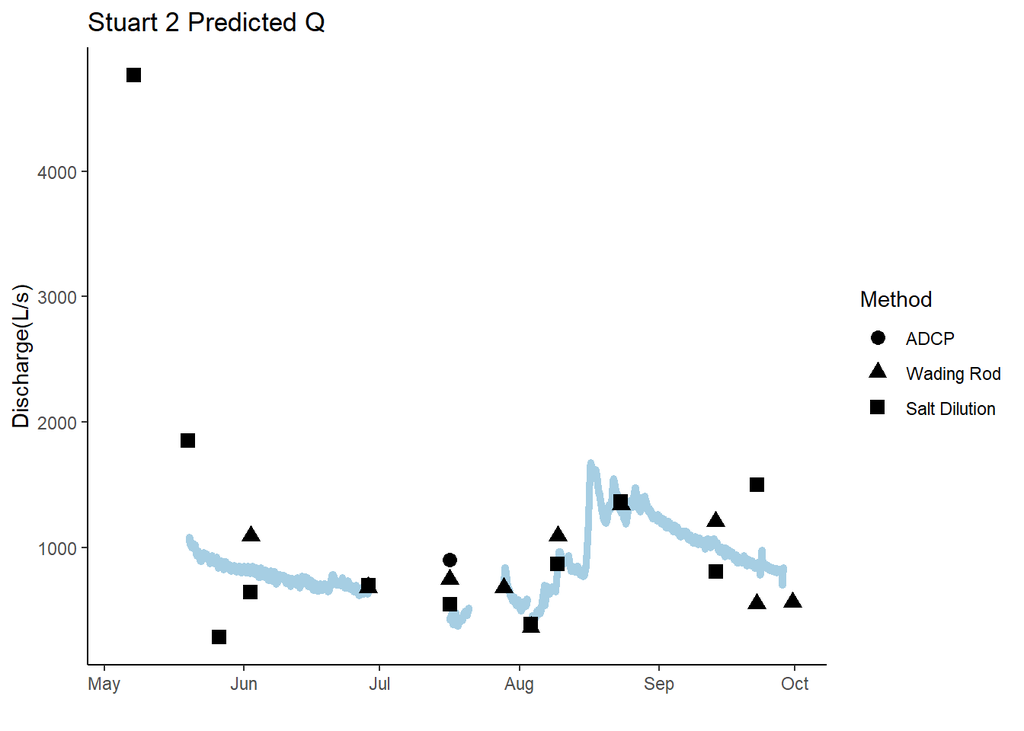

Icky

### Average Q for STRT

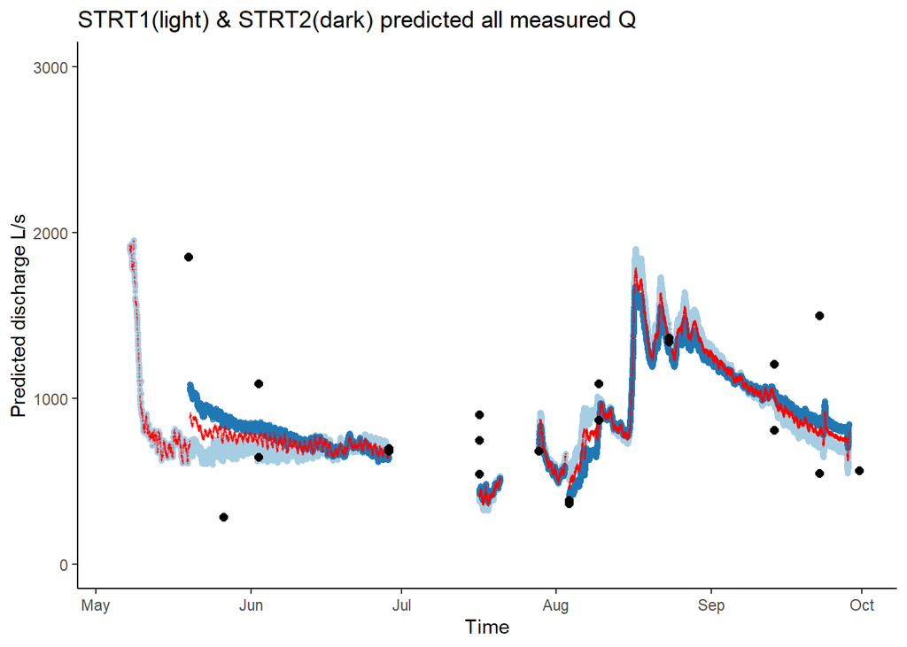

ICKY Lets only use PT2 before July.

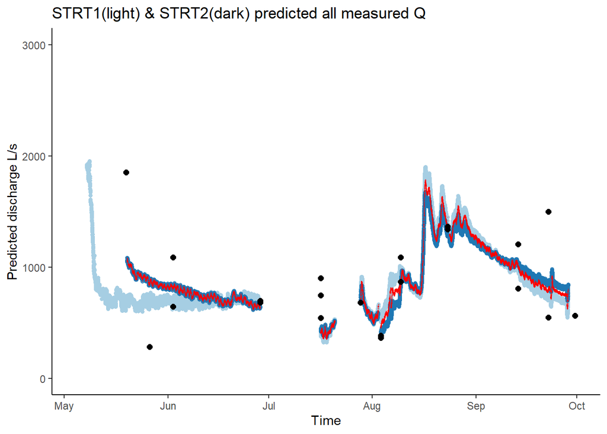

```r
strt.final.discharge.2021 <- strt.final.discharge.2021 %>% mutate(across(c(MeanDischarge), ~ifelse(DateTime < "2021-07-05", pred.strt2.Q,.)))

# Stuart1 (light blue) and Stuart2 (dark blue) with observed Q.
ggplot(aes(x = DateTime, y = pred.strt1.Q), data = strt.final.discharge.2021) +
  geom_point(aes(x = DateTime, y = pred.strt1.Q), data = strt.final.discharge.2021, color="#A6CEE3", size=1.25) +
  geom_point(aes(x = DateTime, y = pred.strt2.Q), data = strt.final.discharge.2021,color="#1F78B4", size=1.25, alpha = 0.75) +
  geom_point(aes(x = DateTime, y = MeanDischarge), data = strt.final.discharge.2021, color = "red", size = 0.25, alpha = 0.25) +
  geom_point(data=Strt2comb.2021, aes(x = DateTime, y = MeasuredQ_Ls), size=2) +
  theme_classic() +
  ylim(0, 3000) +
  ggtitle("STRT1(light) & STRT2(dark) predicted all measured Q") +
  ylab("Predicted discharge L/s") +
  xlab("Time")
```

## Export Q data to csv in DoD_Discharge->Predicted_discharge->2021

## Export PT data to csv in DoD_Discharge->Predicted_discharge->2021

[output not shown]

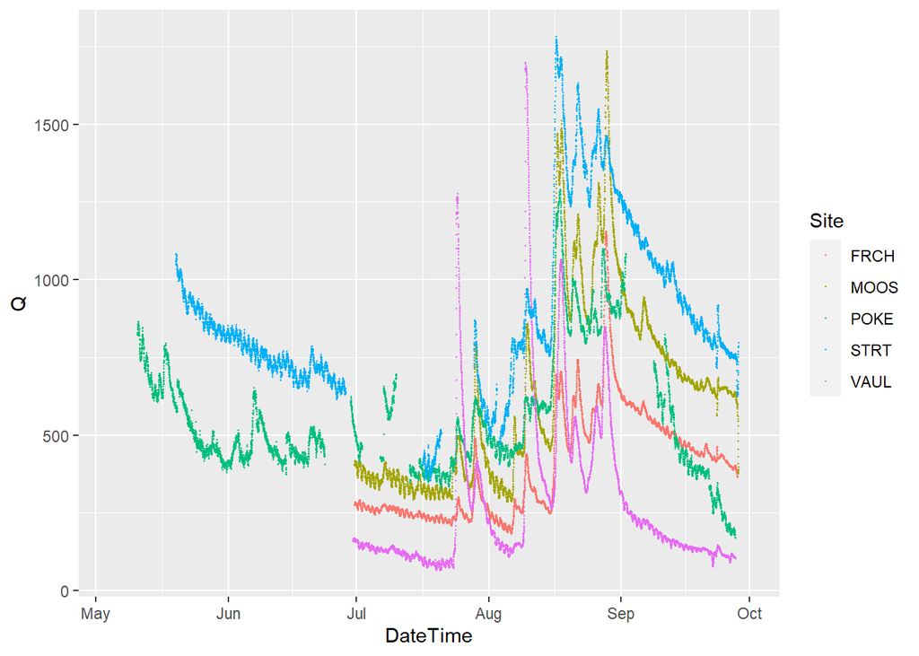

```
## [1]  NA  15 180
```

```
## Defaulting to continuous.
```

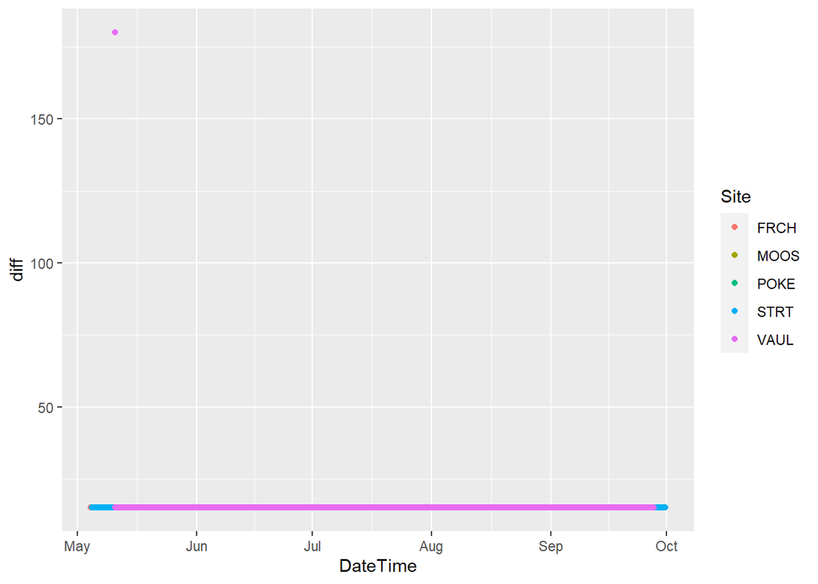

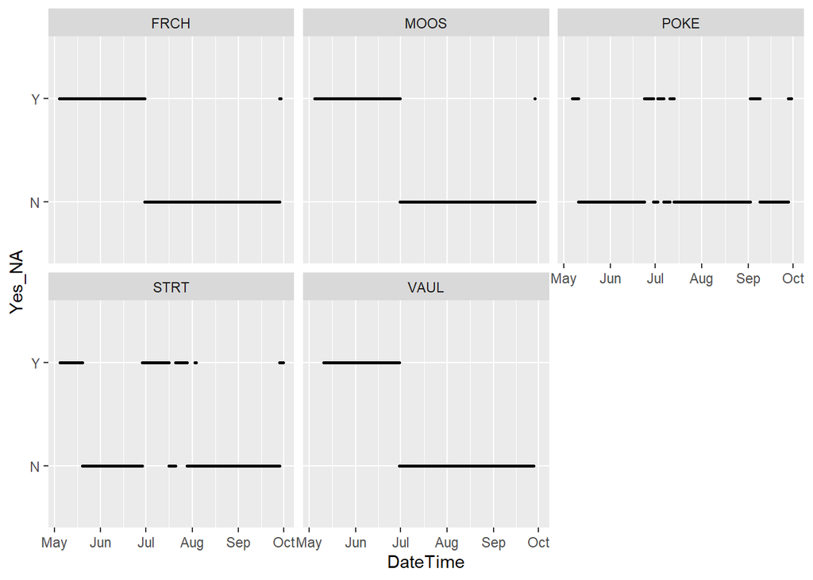